# Linear Mixed Models Workshop

Andrew Stewart

```r
library(tidyverse)
library(Hmisc)
library(lme4)
library(lmerTest)
library(emmeans)
library(visdat)
```

## Linear Mixed Models

Today we are now going to turn to mixed models.

# Q1

Within R, import the dataset “data1.csv”. These data are from a reaction time experiment. Fifty participants had to respond to a word on the screen. Their task was to press a button on a button box only when they recognized the word (our DV is measures in milliseconds). The words were either Rare or Common. The design is repeated measures. We might expect Common words to be recognized more quickly than Common words. Run the appropriate LMM to determine whether this is indeed correct.

```r
data <- read_csv("data1.csv")
```

First we need to make sure that our Subject, Item, and Condition columns are all factors - the first two we will use as our random effects, the third as our fixed effect:

```r
data$Subject <- as.factor(data$Subject)
data$Item <- as.factor(data$Item)
data$Condition <- as.factor(data$Condition)
```

Let’s build a plot:

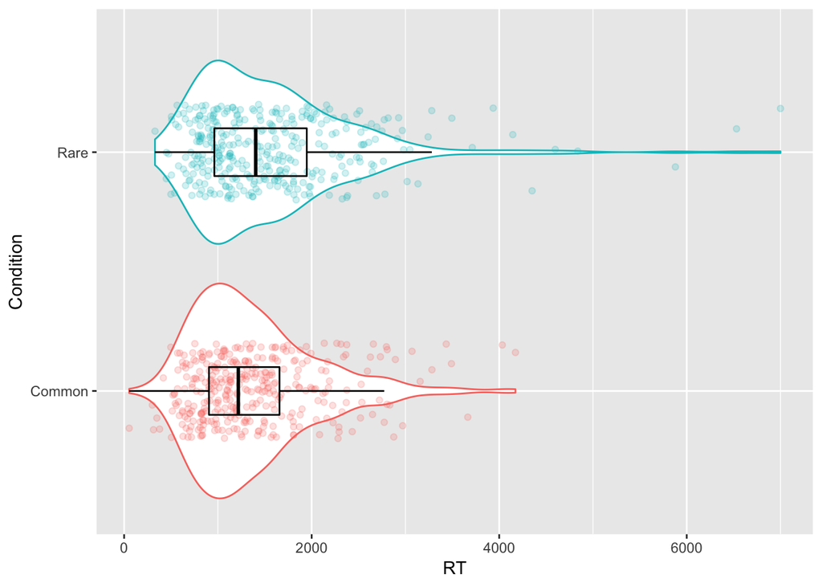

```r
data %>%
  ggplot(aes(x = Condition, y = RT, colour = Condition)) +
  geom_violin() +
  geom_jitter(alpha = .2, width = .2) +
  guides(colour = FALSE) +
  geom_boxplot(width = .2, colour = "black", alpha = 0) +
  coord_flip()
```

Generate some descriptives:

```r
data %>% group_by(Condition) %>%
  filter(!is.na(RT)) %>%
  summarise(mean = mean(RT), sd = sd(RT))
```

```
## # A tibble: 2 x 3
##   Condition  mean    sd
##   <fct>     <dbl> <dbl>
## 1 Common    1370.  658.
## 2 Rare      1563.  864.
```

Let’s run a basic mixed model first:

```r
model1 <- lmer(RT ~ Condition + (1 + Condition | Subject) + (1 + Condition | Item), data = data, REML = TRUE )
summary(model1)
```

```
## Linear mixed model fit by REML. t-tests use Satterthwaite's method [
## lmerModLmerTest]
## Formula: RT ~ Condition + (1 + Condition | Subject) + (1 + Condition |
##     Item)
##    Data: data
##
## REML criterion at convergence: 11077.1
##
## Scaled residuals:
##     Min      1Q  Median      3Q     Max
## -2.0656 -0.5452 -0.1536  0.3564  7.0026
##
## Random effects:
##  Groups   Name          Variance Std.Dev. Corr
##  Subject  (Intercept)    74414   272.8
##           ConditionRare  16588   128.8    -0.01
##  Item     (Intercept)   110706   332.7
##           ConditionRare 125840   354.7    -0.21
##  Residual               364844   604.0
## Number of obs: 699, groups:  Subject, 50; Item, 28
##
## Fixed effects:
##               Estimate Std. Error      df t value Pr(>|t|)
## (Intercept)    1367.51      80.54   38.02  16.980   <2e-16 ***
## ConditionRare   200.10      83.17   25.80   2.406   0.0236 *
## ---
## Signif. codes:  0 '***' 0.001 '**' 0.01 '*' 0.05 '.' 0.1 ' ' 1
##
## Correlation of Fixed Effects:
##             (Intr)
## ConditionRr -0.289
```

We can see we have an effect of condition - the Intercept corresponds to our ‘Common’ condition and our ConditionRare estimate corresponds to the difference between our ‘Common’ and ‘Rare’ conditions. In other words, our ‘Rare’ condition words are about 200 msec. slower to respond to. That fits with the descriptives we calculated earlier. The estimates differ slighly from our descriptives as we have a missing data point which we can see by using the filter() function to display cases where we have missing RT data (indicated by NA).

```r
filter(data, is.na(RT))
```

```
## # A tibble: 1 x 4
##   Subject Item     RT Condition
##   <fct>   <fct> <dbl> <fct>
## 1 21      11       NA Rare
```

How do the residuals look?

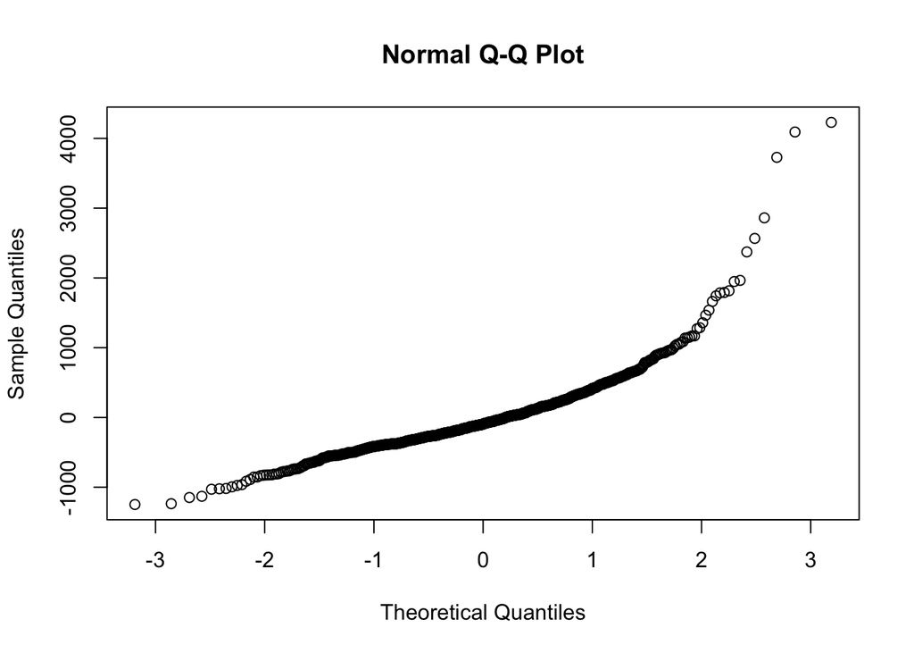

```r
qqnorm(residuals(model1))
```

OK, so these don’t look too normal. We now have a couple of options - we could log transform our DV…

```r
model2 <- lmer(log(RT) ~ Condition + (1 + Condition | Subject) + (1 + Condition| Item), data = data, REML = TRUE)
summary(model2)
```

```
## Linear mixed model fit by REML. t-tests use Satterthwaite's method [
## lmerModLmerTest]
## Formula:
## log(RT) ~ Condition + (1 + Condition | Subject) + (1 + Condition |
##     Item)
##    Data: data
##
## REML criterion at convergence: 736.7
##
## Scaled residuals:
##     Min      1Q  Median      3Q     Max
## -5.5962 -0.5523 -0.0173  0.5480  3.7410
##
## Random effects:
##  Groups   Name          Variance Std.Dev. Corr
##  Subject  (Intercept)   0.056356 0.2374
##           ConditionRare 0.008226 0.0907   -0.76
##  Item     (Intercept)   0.072671 0.2696
##           ConditionRare 0.070676 0.2658   -0.45
##  Residual               0.124800 0.3533
## Number of obs: 699, groups:  Subject, 50; Item, 28
##
## Fixed effects:
##               Estimate Std. Error       df t value Pr(>|t|)
## (Intercept)    7.10880    0.06388 42.85829 111.291   <2e-16 ***
## ConditionRare  0.12612    0.05834 26.89753   2.162   0.0397 *
## ---
## Signif. codes:  0 '***' 0.001 '**' 0.01 '*' 0.05 '.' 0.1 ' ' 1
##
## Correlation of Fixed Effects:
##             (Intr)
## ConditionRr -0.493
```

The same finding holds - with the ‘Rare’ condition taking longer to read. Interpreting the estimates is harder though as they are log transformed… Do the residuals now look normally distributed?

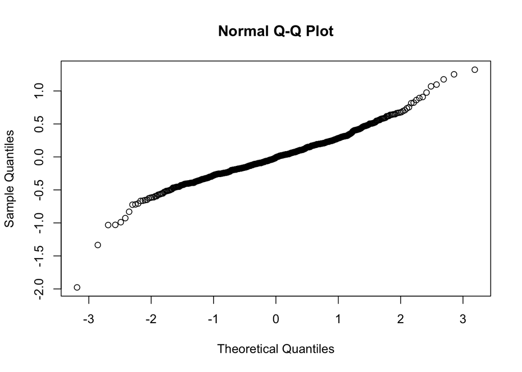

```r
qqnorm(residuals(model2))
```

This is looking better than modelling over the untransformed data. Another option would be to build a generalised linear mixed model assuming sampling from the Gamma distribution.

# Q2

Within R, import the dataset “data2.csv”. These data are from an experiment where we measured how long people spent looking at images that appeared on screen. The images depicted either positive, neutral, or negative scenes. This is our one factor with three levels. The design was repeated measures. Perform the appropriate LMM analysis and determine whether people spent a different amount of time looking at the positive relative to the negative images, and the neutral relative to the negative images.

First we need to set our appropriate factors.

```r
data$Subject <- as.factor(data$Subject)
data$Item <- as.factor(data$Item)
data$Image <- as.factor(data$Image)
```

Let’s visual our data:

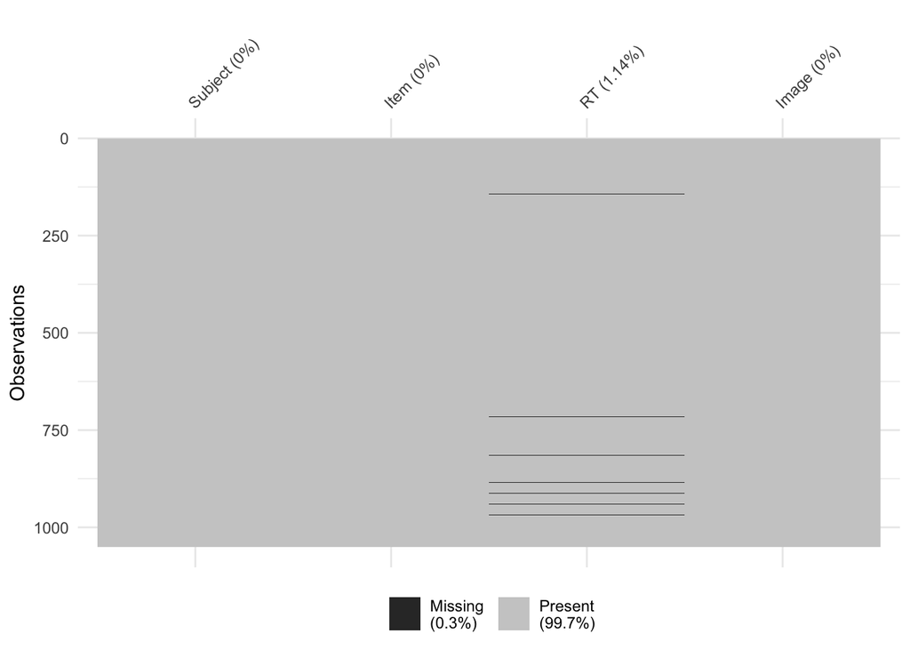

```r
vis_miss(data)
```

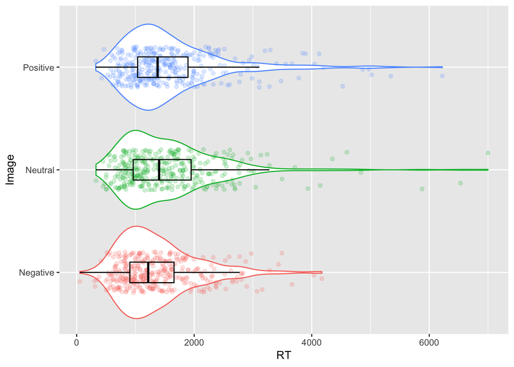

```r
data %>%
  ggplot(aes (x = Image, y = RT, colour = Image)) +
  geom_violin() +
  geom_jitter(alpha = .2, width = .2) +
  guides(colour = FALSE) +
  geom_boxplot(width = .2, colour = "black", alpha = 0) +
  coord_flip()
```

We have some missing data so need to use na.rm = TRUE to ignore those points.

```r
data %>%
  group_by(Image) %>%
  summarise(mean = mean(RT, na.rm = TRUE), sd = sd(RT, na.rm = TRUE))
```

```
## # A tibble: 3 x 3
##   Image     mean    sd
##   <fct>    <dbl> <dbl>
## 1 Negative 1370.  658.
## 2 Neutral  1563.  864.
## 3 Positive 1591.  855.
```

Let’s build our model.

```r
model <- lmer(RT ~ Image + (1 + Image| Subject) + (1 + Image| Item), data = data, REML = TRUE)
```

```
## singular fit
```

```r
summary(model)
```

```
## Linear mixed model fit by REML. t-tests use Satterthwaite's method [
## lmerModLmerTest]
## Formula: RT ~ Image + (1 + Image | Subject) + (1 + Image | Item)
##    Data: data
##
## REML criterion at convergence: 16492.5
##
## Scaled residuals:
##     Min      1Q  Median      3Q     Max
## -2.0189 -0.5608 -0.1722  0.3372  6.8963
##
## Random effects:
##  Groups   Name          Variance Std.Dev. Corr
##  Subject  (Intercept)    72803   269.82
##           ImageNeutral   12369   111.22    0.04
##           ImagePositive  27139   164.74    0.38 -0.91
##  Item     (Intercept)   108388   329.22
##           ImageNeutral  128010   357.79   -0.21
##           ImagePositive   6096    78.08    0.96 -0.48
##  Residual               391081   625.36
## Number of obs: 1038, groups:  Subject, 50; Item, 28
##
## Fixed effects:
##               Estimate Std. Error      df t value Pr(>|t|)
## (Intercept)    1368.08      80.28   39.77  17.041  < 2e-16 ***
## ImageNeutral    199.62      84.03   27.32   2.376 0.024784 *
## ImagePositive   212.19      55.37   57.96   3.832 0.000315 ***
## ---
## Signif. codes:  0 '***' 0.001 '**' 0.01 '*' 0.05 '.' 0.1 ' ' 1
##
## Correlation of Fixed Effects:
##             (Intr) ImgNtr
## ImageNeutrl -0.295
## ImagePositv  0.023  0.067
## convergence code: 0
## singular fit
```

How do the residuals look?

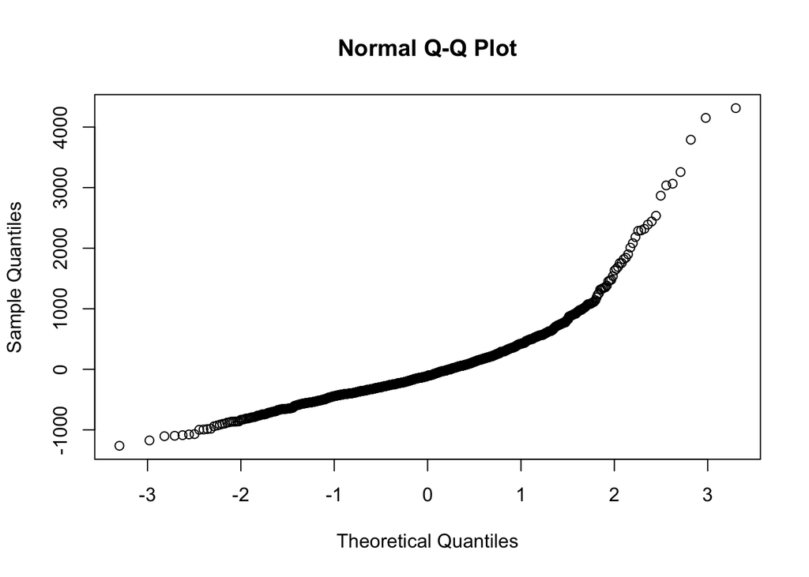

```r
qqnorm(residuals(model))
```

OK, maybe we should log transform the data:

```r
model <- lmer(log(RT) ~ Image + (1 + Image | Subject) + (1 + Image | Item), data = data, REML = TRUE)
```

```
## singular fit
```

```r
summary(model)
```

```
## Linear mixed model fit by REML. t-tests use Satterthwaite's method [
## lmerModLmerTest]
## Formula: log(RT) ~ Image + (1 + Image | Subject) + (1 + Image | Item)
##    Data: data
##
## REML criterion at convergence: 1024.2
##
## Scaled residuals:
##     Min      1Q  Median      3Q     Max
## -5.7652 -0.6323 -0.0621  0.5402  3.8502
##
## Random effects:
##  Groups   Name          Variance  Std.Dev. Corr
##  Subject  (Intercept)   0.0565024 0.23770
##           ImageNeutral  0.0092828 0.09635  -0.74
##           ImagePositive 0.0181080 0.13457  -0.43  0.47
##  Item     (Intercept)   0.0714191 0.26724
##           ImageNeutral  0.0736925 0.27146  -0.44
##           ImagePositive 0.0004923 0.02219  -0.99  0.29
##  Residual               0.1212256 0.34817
## Number of obs: 1038, groups:  Subject, 50; Item, 28
##
## Fixed effects:
##               Estimate Std. Error       df t value Pr(>|t|)
## (Intercept)    7.10941    0.06346 44.76973 112.023  < 2e-16 ***
## ImageNeutral   0.12574    0.05926 27.79887   2.122 0.042916 *
## ImagePositive  0.13998    0.03305 47.12836   4.236 0.000105 ***
## ---
## Signif. codes:  0 '***' 0.001 '**' 0.01 '*' 0.05 '.' 0.1 ' ' 1
##
## Correlation of Fixed Effects:
##             (Intr) ImgNtr
## ImageNeutrl -0.486
## ImagePositv -0.395  0.271
## convergence code: 0
## singular fit
```

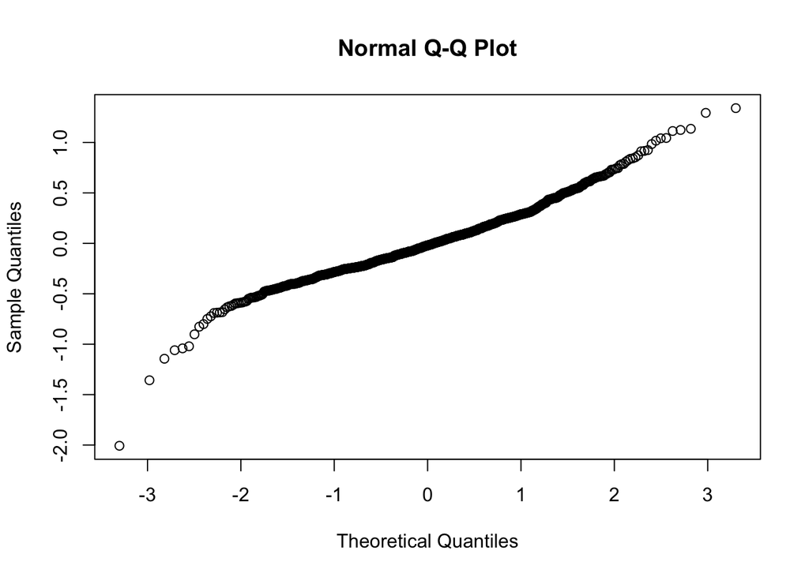

```r
qqnorm(residuals(model))
```

OK, with log transformed data our residuals look a lot better. We find that the Neutral and Positive conditions differ from the Negative.

# Q3

Now we’re going to import the dataset “data3.csv”. These data are from a repeated measures experiment where participants had to respond to a target word (measured by our DV which is labelled “Time”). The target word always followed a prime word. Prime and Target are our two factors – each with two levels – Positive vs. Negative. We are interested in whether there is a priming effect (i.e., Positive target words responded to more quickly after Positive than after Negative Primes, and Negative target words responded to more quickly after Negative than after Positive Primes). We need to build the appropriate LMM to determine whether this is indeed correct.

```r
data <- read_csv("data3.csv")
```

First we need to create our factors:

```r
data$Subject <- as.factor(data$Subject)
data$Item <- as.factor(data$Item)
data$Prime <- as.factor(data$Prime)
data$Target <- as.factor(data$Target)
```

As it is a factorial experiment, we need to set up our contrast weightings for our two factors. This allows for easier intepretation of the paramester estimates - the intercept will correspond to the Grand Mean (i.e., the mean of our conditions).

```r
contrasts(data$Prime) <- matrix(c(.5, -.5))
contrasts(data$Target) <- matrix(c(.5, -.5))
```

We can now check the structure of our data:

```r
head(data)
```

```
## # A tibble: 6 x 5
##   Subject Item   Time Prime    Target
##   <fct>   <fct> <dbl> <fct>    <fct>
## 1 1       3       407 Negative Negative
## 2 1       7       367 Negative Negative
## 3 1       11      352 Negative Negative
## 4 1       15      293 Negative Negative
## 5 1       19      227 Negative Negative
## 6 1       23      497 Negative Negative
```

Let’s visualise our data:

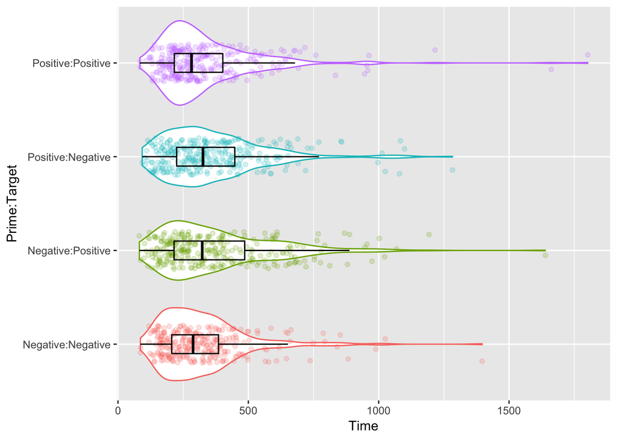

```r
data %>%
  ggplot(aes(x = Prime:Target, y = Time, colour = Prime:Target)) +
  geom_violin() +
  geom_jitter(alpha = .2, width = .2) +
  guides(colour = FALSE) +
  geom_boxplot(width = .2, colour = "black", alpha = 0) +
  coord_flip()
```

Now we are going to generate some descriptives, filtering out cases where we have missing data in our dependent variable (labelled “Time”).

```r
data %>%
  filter(!is.na(Time)) %>%
  group_by(Prime, Target) %>%
  summarise(mean = mean(Time), sd = sd(Time))
```

```
## # A tibble: 4 x 4
## # Groups:   Prime [?]
##   Prime    Target    mean    sd
##   <fct>    <fct>    <dbl> <dbl>
## 1 Negative Negative  321.  167.
## 2 Negative Positive  376.  219.
## 3 Positive Negative  361.  191.
## 4 Positive Positive  337.  203.
```

```r
data %>% filter(is.na(Time))
```

```
## # A tibble: 121 x 5
##    Subject Item   Time Prime    Target
##    <fct>   <fct> <dbl> <fct>    <fct>
##  1 1       29       NA Positive Positive
##  2 4       27       NA Negative Negative
##  3 4       24       NA Negative Positive
##  4 5       24       NA Negative Positive
##  5 5       30       NA Positive Negative
##  6 6       19       NA Negative Negative
##  7 6       12       NA Negative Positive
##  8 6       14       NA Positive Negative
##  9 7       3        NA Negative Negative
## 10 7       11       NA Negative Negative
## # … with 111 more rows
```

Note we have a little missing data (121 rows) - not a big deal, but something that you could report.

We could calculate and plot the amount of missing data per participant:

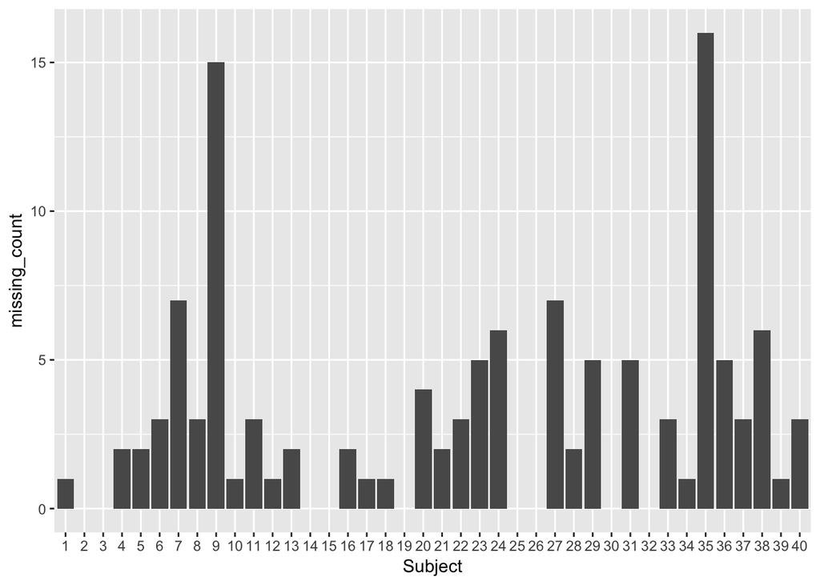

```r
data %>%
  group_by(Subject) %>%
  summarise(missing_count = sum(is.na(Time))) %>%
  ggplot(aes(x = Subject, y = missing_count)) +
  geom_col()
```

```r
model <- lmer(Time ~ Prime * Target + (1 + Prime * Target | Subject) + (1 + Prime * Target | Item), data = data, REML = TRUE)
```

```
## singular fit
```

```r
summary(model)
```

```
## Linear mixed model fit by REML. t-tests use Satterthwaite's method [
## lmerModLmerTest]
## Formula: Time ~ Prime * Target + (1 + Prime * Target | Subject) + (1 +
##     Prime * Target | Item)
##    Data: data
##
## REML criterion at convergence: 15336.5
##
## Scaled residuals:
##     Min      1Q  Median      3Q     Max
## -3.0636 -0.6074 -0.1822  0.4064  6.4657
##
## Random effects:
##  Groups   Name           Variance Std.Dev. Corr
##  Subject  (Intercept)     6091.3   78.05
##           Prime1           803.2   28.34    0.23
##           Target1         2165.8   46.54   -0.55 -0.94
##           Prime1:Target1   292.3   17.10   -0.57  0.67 -0.37
##  Item     (Intercept)     1439.1   37.94
##           Prime1           237.6   15.41   -0.77
##           Target1          136.4   11.68   -1.00  0.78
##           Prime1:Target1   402.8   20.07   -0.93  0.49  0.93
##  Residual                30083.9  173.45
## Number of obs: 1159, groups:  Subject, 40; Item, 32
##
## Fixed effects:
##                 Estimate Std. Error        df t value Pr(>|t|)
## (Intercept)    344.37358   14.95681  51.23332  23.025  < 2e-16 ***
## Prime1          -0.05088   11.48888  32.71103  -0.004 0.996494
## Target1        -15.26291   12.77283  47.68283  -1.195 0.238016
## Prime1:Target1 -77.24873   20.91635 178.03556  -3.693 0.000294 ***
## ---
## Signif. codes:  0 '***' 0.001 '**' 0.01 '*' 0.05 '.' 0.1 ' ' 1
##
## Correlation of Fixed Effects:
##             (Intr) Prime1 Targt1
## Prime1      -0.005
## Target1     -0.330 -0.178
## Prim1:Trgt1 -0.129  0.057  0.005
## convergence code: 0
## singular fit
```

This suggests our model is over-parameterised - the “singular fit” message tells us we have combinations of our effects where some dimensions of the variance-covariance matrix in our model are effectively zero. In other words, we are trying to estimate more parameters than our data will allow. In practice you might want to simplify your random effects structure until you find a model that isn’t over parameterised. For the time being, let’s stick with this model.

Our interaction is significant - we now need to run pairwise comparisons to figure out what condition(s) differs from what other condition(s). We need to use the emmeans() function from the emmeans package - let’s do the correction manually as only a couple of pairwise comparisons make theoretical sense. They are Positive/Positive vs Negative/Positive, and Negative/Negative vs Positive/Negative. These are the only pairs where we’re comparing the same target to the same target under the two different levels of our prime. So, we need to multiply by 2 the calculated p-values for these comparisons to correct for familywise error.

```r
emmeans(model, pairwise ~ Prime * Target, adjust = "none")
```

[output not shown]

What do the residuals look like?

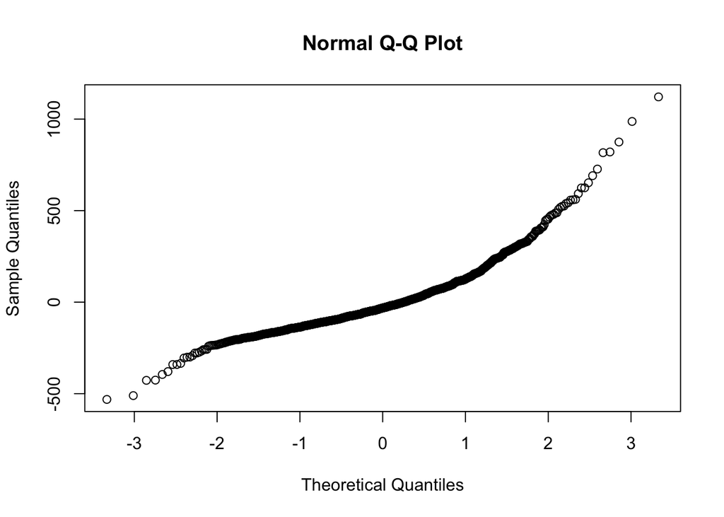

```r
qqnorm(residuals(model))
```

The above residuals don’t look brilliant. What about log transform? The most complex random effects model we can build is this one (although it looks over-parameterised):

```r
model <- lmer(log(Time) ~ Prime * Target + (1 + Prime * Target | Subject) + (1 + Prime * Target | Item), data = data, REML = TRUE)
```

```
## singular fit
```

```r
summary(model)
```

```
## Linear mixed model fit by REML. t-tests use Satterthwaite's method [
## lmerModLmerTest]
## Formula: log(Time) ~ Prime * Target + (1 + Prime * Target | Subject) +
##     (1 + Prime * Target | Item)
##    Data: data
##
## REML criterion at convergence: 1509.6
##
## Scaled residuals:
##     Min      1Q  Median      3Q     Max
## -2.8696 -0.6773 -0.0318  0.6279  3.1848
##
## Random effects:
##  Groups   Name           Variance  Std.Dev. Corr
##  Subject  (Intercept)    0.0472876 0.21746
##           Prime1         0.0061354 0.07833   0.64
##           Target1        0.0054936 0.07412  -0.17 -0.87
##           Prime1:Target1 0.0078593 0.08865  -1.00 -0.69  0.25
##  Item     (Intercept)    0.0090350 0.09505
##           Prime1         0.0015000 0.03873  -0.95
##           Target1        0.0004729 0.02175  -0.96  0.81
##           Prime1:Target1 0.0001890 0.01375   0.15  0.18 -0.42
##  Residual                0.1901889 0.43611
## Number of obs: 1159, groups:  Subject, 40; Item, 32
##
## Fixed effects:
##                  Estimate Std. Error         df t value Pr(>|t|)
## (Intercept)      5.711416   0.040396  49.590781 141.385  < 2e-16 ***
## Prime1          -0.009569   0.029333  40.142804  -0.326  0.74595
## Target1         -0.026724   0.028531  53.437917  -0.937  0.35316
## Prime1:Target1  -0.181359   0.053287 169.580473  -3.403  0.00083 ***
## ---
## Signif. codes:  0 '***' 0.001 '**' 0.01 '*' 0.05 '.' 0.1 ' ' 1
##
## Correlation of Fixed Effects:
##             (Intr) Prime1 Targt1
## Prime1       0.140
## Target1     -0.112 -0.121
## Prim1:Trgt1 -0.218 -0.070  0.034
## convergence code: 0
## singular fit
```

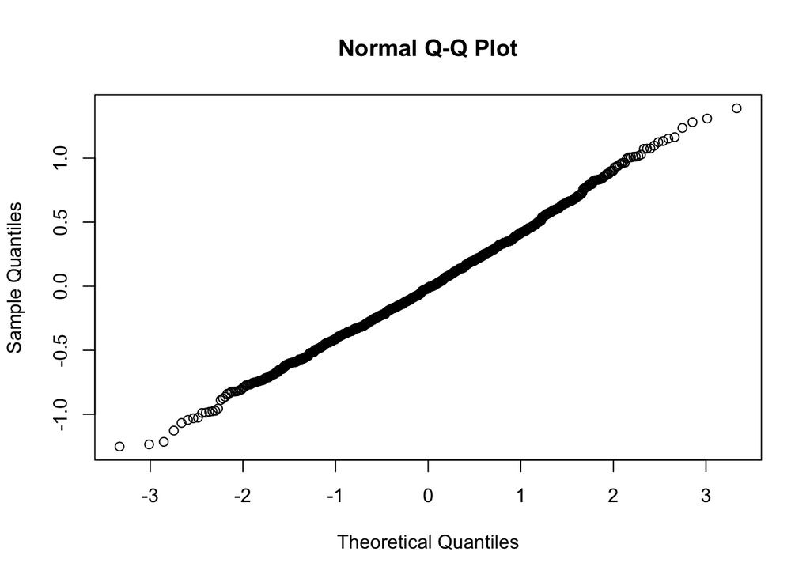

```r
qqnorm(residuals(model))
```

To aid interpretation of our results, we want our comparisons to be reported on the response scale rather thanon the log scale - so we need to specify this when we call the emmeans() function by setting the parameter type to equal “response”.

```r
emmeans(model, pairwise ~ Prime * Target, adjust = "none", type = "response")
```

[output not shown]

Again we see the pairwise comparisons don’t survive familywise error correction. In this case we might start to wonder about our experimental power. As a rule of thumb, you need around 1600 observations per condition to detect the kinds of effect sizes we’re looking for:

[figure not shown]

Brysbaert, M. & Stevens, M. (2018). Power Analysis and Effect Size in Mixed Effects Models: A Tutorial. *Journal of Cognition, 1*, 1–20, DOI: https://doi.org/10.5334/joc.10

How many observations did we have per condition?

```r
data %>% group_by(Prime, Target) %>% summarise(count = n())
```

```
## # A tibble: 4 x 3
## # Groups:   Prime [?]
##   Prime    Target   count
##   <fct>    <fct>    <int>
## 1 Negative Negative   320
## 2 Negative Positive   320
## 3 Positive Negative   320
## 4 Positive Positive   320
```

We need to run a much higher powered experiment - we need to increase the number of participants, the number of trials, or both!

What about calculating the Bayes factor in support of the experimental vs. the null hypothesis? Have a look at the slides from this morning about how to do that…